# Risk Factor Analysis

## Outcome Variable

**Outcome Variable:** sstunted

## Predictor Variables

**Intervention Variable:** tr

**Adjustment Set:**

unadjusted

## Stratifying Variables

The analysis was stratified on these variable(s):

- agecat
- studyid
- country
- intXenstunt

## Data Summary

| agecat | studyid | country | intXenstunt | sstunted | n_cell | n |
| --- | --- | --- | --- | --- | --- | --- |
| Birth | iLiNS_DYADM_LNS | MALAWI | 1_Birth | 0 | 0 | 1 |
| Birth | iLiNS_DYADM_LNS | MALAWI | 1_Birth | 1 | 1 | 1 |
| Birth | ki1000125-AgaKhanUniv | PAKISTAN | 0_Birth | 0 | 11 | 11 |
| Birth | ki1000125-AgaKhanUniv | PAKISTAN | 0_Birth | 1 | 0 | 11 |
| Birth | ki1000304b-SAS-CompFeed | INDIA | 0_Birth | 0 | 106 | 106 |
| Birth | ki1000304b-SAS-CompFeed | INDIA | 0_Birth | 1 | 0 | 106 |
| Birth | ki1000304b-SAS-CompFeed | INDIA | 1_Birth | 0 | 27 | 38 |
| Birth | ki1000304b-SAS-CompFeed | INDIA | 1_Birth | 1 | 11 | 38 |
| Birth | ki1119695-PROBIT | BELARUS | 0_Birth | 0 | 13851 | 13851 |
| Birth | ki1119695-PROBIT | BELARUS | 0_Birth | 1 | 0 | 13851 |
| Birth | ki1119695-PROBIT | BELARUS | 1_Birth | 0 | 28 | 33 |
| Birth | ki1119695-PROBIT | BELARUS | 1_Birth | 1 | 5 | 33 |
| Birth | ki1126311-ZVITAMBO | ZIMBABWE | 0_Birth | 0 | 12398 | 12398 |
| Birth | ki1126311-ZVITAMBO | ZIMBABWE | 0_Birth | 1 | 0 | 12398 |
| Birth | ki1126311-ZVITAMBO | ZIMBABWE | 1_Birth | 0 | 991 | 1432 |
| Birth | ki1126311-ZVITAMBO | ZIMBABWE | 1_Birth | 1 | 441 | 1432 |
| Birth | ki1135781-COHORTS | GUATEMALA | 0_Birth | 0 | 802 | 802 |
| Birth | ki1135781-COHORTS | GUATEMALA | 0_Birth | 1 | 0 | 802 |
| Birth | ki1135781-COHORTS | GUATEMALA | 1_Birth | 0 | 39 | 50 |
| Birth | ki1135781-COHORTS | GUATEMALA | 1_Birth | 1 | 11 | 50 |
| Birth | ki1148112-iLiNS-DYAD-M | MALAWI | 1_Birth | 0 | 0 | 1 |
| Birth | ki1148112-iLiNS-DYAD-M | MALAWI | 1_Birth | 1 | 1 | 1 |
| Birth | kiGH5241-JiVitA-3 | BANGLADESH | 0_Birth | 0 | 26550 | 26550 |
| Birth | kiGH5241-JiVitA-3 | BANGLADESH | 0_Birth | 1 | 0 | 26550 |
| Birth | kiGH5241-JiVitA-3 | BANGLADESH | 1_Birth | 0 | 8594 | 12676 |
| Birth | kiGH5241-JiVitA-3 | BANGLADESH | 1_Birth | 1 | 4082 | 12676 |
| Birth | kiGH5241-JiVitA-4 | BANGLADESH | 0_Birth | 0 | 1150 | 1150 |
| Birth | kiGH5241-JiVitA-4 | BANGLADESH | 0_Birth | 1 | 0 | 1150 |
| Birth | kiGH5241-JiVitA-4 | BANGLADESH | 1_Birth | 0 | 366 | 494 |
| Birth | kiGH5241-JiVitA-4 | BANGLADESH | 1_Birth | 1 | 128 | 494 |

[output cut: 164 more lines]

The following strata were considered:

- agecat: 24 months, studyid: iLiNS_DYADM_LNS, country: MALAWI, intXenstunt: 0_24 months
- agecat: 24 months, studyid: iLiNS_DYADM_LNS, country: MALAWI, intXenstunt: 1_24 months
- agecat: 24 months, studyid: ki1000107-Serrinha-VitA, country: BRAZIL, intXenstunt: 0_24 months
- agecat: 24 months, studyid: ki1000107-Serrinha-VitA, country: BRAZIL, intXenstunt: 1_24 months
- agecat: 24 months, studyid: ki1000110-WASH-Bangladesh, country: BANGLADESH, intXenstunt: 0_24 months
- agecat: 24 months, studyid: ki1000110-WASH-Bangladesh, country: BANGLADESH, intXenstunt: 1_24 months
- agecat: 24 months, studyid: ki1000111-WASH-Kenya, country: KENYA, intXenstunt: 0_24 months
- agecat: 24 months, studyid: ki1000111-WASH-Kenya, country: KENYA, intXenstunt: 1_24 months
- agecat: 24 months, studyid: ki1000125-AgaKhanUniv, country: PAKISTAN, intXenstunt: 0_24 months
- agecat: 24 months, studyid: ki1000125-AgaKhanUniv, country: PAKISTAN, intXenstunt: 1_24 months
- agecat: 24 months, studyid: ki1000304-EU, country: INDIA, intXenstunt: 0_24 months
- agecat: 24 months, studyid: ki1000304-EU, country: INDIA, intXenstunt: 1_24 months
- agecat: 24 months, studyid: ki1000304-Vitamin-B12, country: INDIA, intXenstunt: 0_24 months
- agecat: 24 months, studyid: ki1000304-Vitamin-B12, country: INDIA, intXenstunt: 1_24 months
- agecat: 24 months, studyid: ki1000304-ZnMort, country: INDIA, intXenstunt: 0_24 months
- agecat: 24 months, studyid: ki1000304-ZnMort, country: INDIA, intXenstunt: 1_24 months
- agecat: 24 months, studyid: ki1017093b-PROVIDE, country: BANGLADESH, intXenstunt: 0_24 months
- agecat: 24 months, studyid: ki1066203-TanzaniaChild2, country: TANZANIA, UNITED REPUBLIC OF, intXenstunt: 0_24 months
- agecat: 24 months, studyid: ki1112895-Burkina Faso Zn, country: BURKINA FASO, intXenstunt: 0_24 months
- agecat: 24 months, studyid: ki1112895-Burkina Faso Zn, country: BURKINA FASO, intXenstunt: 1_24 months
- agecat: 24 months, studyid: ki1119695-PROBIT, country: BELARUS, intXenstunt: 0_24 months
- agecat: 24 months, studyid: ki1119695-PROBIT, country: BELARUS, intXenstunt: 1_24 months
- agecat: 24 months, studyid: ki1126311-ZVITAMBO, country: ZIMBABWE, intXenstunt: 0_24 months
- agecat: 24 months, studyid: ki1126311-ZVITAMBO, country: ZIMBABWE, intXenstunt: 1_24 months
- agecat: 24 months, studyid: ki1135781-COHORTS, country: GUATEMALA, intXenstunt: 0_24 months
- agecat: 24 months, studyid: ki1135781-COHORTS, country: GUATEMALA, intXenstunt: 1_24 months
- agecat: 24 months, studyid: ki1148112-iLiNS-DOSE, country: MALAWI, intXenstunt: 0_24 months
- agecat: 24 months, studyid: ki1148112-iLiNS-DOSE, country: MALAWI, intXenstunt: 1_24 months
- agecat: 24 months, studyid: ki1148112-iLiNS-DYAD-M, country: MALAWI, intXenstunt: 0_24 months
- agecat: 24 months, studyid: ki1148112-iLiNS-DYAD-M, country: MALAWI, intXenstunt: 1_24 months
- agecat: 24 months, studyid: ki1148112-LCNI-5, country: MALAWI, intXenstunt: 0_24 months
- agecat: 24 months, studyid: ki1148112-LCNI-5, country: MALAWI, intXenstunt: 1_24 months
- agecat: 24 months, studyid: kiGH5241-JiVitA-3, country: BANGLADESH, intXenstunt: 0_24 months
- agecat: 24 months, studyid: kiGH5241-JiVitA-3, country: BANGLADESH, intXenstunt: 1_24 months
- agecat: 24 months, studyid: kiGH5241-JiVitA-4, country: BANGLADESH, intXenstunt: 0_24 months
- agecat: 24 months, studyid: kiGH5241-JiVitA-4, country: BANGLADESH, intXenstunt: 1_24 months
- agecat: 6 months, studyid: iLiNS_DYADM_LNS, country: MALAWI, intXenstunt: 0_6 months
- agecat: 6 months, studyid: iLiNS_DYADM_LNS, country: MALAWI, intXenstunt: 1_6 months
- agecat: 6 months, studyid: ki1000107-Serrinha-VitA, country: BRAZIL, intXenstunt: 0_6 months
- agecat: 6 months, studyid: ki1000107-Serrinha-VitA, country: BRAZIL, intXenstunt: 1_6 months
- agecat: 6 months, studyid: ki1000110-WASH-Bangladesh, country: BANGLADESH, intXenstunt: 0_6 months
- agecat: 6 months, studyid: ki1000110-WASH-Bangladesh, country: BANGLADESH, intXenstunt: 1_6 months
- agecat: 6 months, studyid: ki1000111-WASH-Kenya, country: KENYA, intXenstunt: 0_6 months
- agecat: 6 months, studyid: ki1000111-WASH-Kenya, country: KENYA, intXenstunt: 1_6 months
- agecat: 6 months, studyid: ki1000125-AgaKhanUniv, country: PAKISTAN, intXenstunt: 0_6 months
- agecat: 6 months, studyid: ki1000125-AgaKhanUniv, country: PAKISTAN, intXenstunt: 1_6 months
- agecat: 6 months, studyid: ki1000304-EU, country: INDIA, intXenstunt: 0_6 months
- agecat: 6 months, studyid: ki1000304-EU, country: INDIA, intXenstunt: 1_6 months
- agecat: 6 months, studyid: ki1000304-VITAMIN-A, country: INDIA, intXenstunt: 0_6 months
- agecat: 6 months, studyid: ki1000304-VITAMIN-A, country: INDIA, intXenstunt: 1_6 months
- agecat: 6 months, studyid: ki1000304-Vitamin-B12, country: INDIA, intXenstunt: 0_6 months
- agecat: 6 months, studyid: ki1000304-Vitamin-B12, country: INDIA, intXenstunt: 1_6 months
- agecat: 6 months, studyid: ki1000304-ZnMort, country: INDIA, intXenstunt: 0_6 months
- agecat: 6 months, studyid: ki1000304-ZnMort, country: INDIA, intXenstunt: 1_6 months
- agecat: 6 months, studyid: ki1000304b-SAS-CompFeed, country: INDIA, intXenstunt: 0_6 months
- agecat: 6 months, studyid: ki1000304b-SAS-CompFeed, country: INDIA, intXenstunt: 1_6 months
- agecat: 6 months, studyid: ki1000304b-SAS-FoodSuppl, country: INDIA, intXenstunt: 0_6 months
- agecat: 6 months, studyid: ki1000304b-SAS-FoodSuppl, country: INDIA, intXenstunt: 1_6 months
- agecat: 6 months, studyid: ki1017093b-PROVIDE, country: BANGLADESH, intXenstunt: 0_6 months
- agecat: 6 months, studyid: ki1017093b-PROVIDE, country: BANGLADESH, intXenstunt: 1_6 months
- agecat: 6 months, studyid: ki1066203-TanzaniaChild2, country: TANZANIA, UNITED REPUBLIC OF, intXenstunt: 0_6 months
- agecat: 6 months, studyid: ki1066203-TanzaniaChild2, country: TANZANIA, UNITED REPUBLIC OF, intXenstunt: 1_6 months
- agecat: 6 months, studyid: ki1112895-Burkina Faso Zn, country: BURKINA FASO, intXenstunt: 0_6 months
- agecat: 6 months, studyid: ki1112895-Burkina Faso Zn, country: BURKINA FASO, intXenstunt: 1_6 months
- agecat: 6 months, studyid: ki1112895-Guatemala BSC, country: GUATEMALA, intXenstunt: 0_6 months
- agecat: 6 months, studyid: ki1112895-Guatemala BSC, country: GUATEMALA, intXenstunt: 1_6 months
- agecat: 6 months, studyid: ki1119695-PROBIT, country: BELARUS, intXenstunt: 0_6 months
- agecat: 6 months, studyid: ki1119695-PROBIT, country: BELARUS, intXenstunt: 1_6 months
- agecat: 6 months, studyid: ki1126311-ZVITAMBO, country: ZIMBABWE, intXenstunt: 0_6 months
- agecat: 6 months, studyid: ki1126311-ZVITAMBO, country: ZIMBABWE, intXenstunt: 1_6 months
- agecat: 6 months, studyid: ki1135781-COHORTS, country: GUATEMALA, intXenstunt: 0_6 months
- agecat: 6 months, studyid: ki1135781-COHORTS, country: GUATEMALA, intXenstunt: 1_6 months
- agecat: 6 months, studyid: ki1148112-iLiNS-DOSE, country: MALAWI, intXenstunt: 0_6 months
- agecat: 6 months, studyid: ki1148112-iLiNS-DOSE, country: MALAWI, intXenstunt: 1_6 months
- agecat: 6 months, studyid: ki1148112-iLiNS-DYAD-M, country: MALAWI, intXenstunt: 0_6 months
- agecat: 6 months, studyid: ki1148112-iLiNS-DYAD-M, country: MALAWI, intXenstunt: 1_6 months
- agecat: 6 months, studyid: ki1148112-LCNI-5, country: MALAWI, intXenstunt: 0_6 months
- agecat: 6 months, studyid: ki1148112-LCNI-5, country: MALAWI, intXenstunt: 1_6 months
- agecat: 6 months, studyid: kiGH5241-JiVitA-3, country: BANGLADESH, intXenstunt: 0_6 months
- agecat: 6 months, studyid: kiGH5241-JiVitA-3, country: BANGLADESH, intXenstunt: 1_6 months
- agecat: 6 months, studyid: kiGH5241-JiVitA-4, country: BANGLADESH, intXenstunt: 0_6 months
- agecat: 6 months, studyid: kiGH5241-JiVitA-4, country: BANGLADESH, intXenstunt: 1_6 months
- agecat: Birth, studyid: iLiNS_DYADM_LNS, country: MALAWI, intXenstunt: 1_Birth
- agecat: Birth, studyid: ki1000125-AgaKhanUniv, country: PAKISTAN, intXenstunt: 0_Birth
- agecat: Birth, studyid: ki1000304b-SAS-CompFeed, country: INDIA, intXenstunt: 0_Birth
- agecat: Birth, studyid: ki1000304b-SAS-CompFeed, country: INDIA, intXenstunt: 1_Birth
- agecat: Birth, studyid: ki1119695-PROBIT, country: BELARUS, intXenstunt: 0_Birth
- agecat: Birth, studyid: ki1119695-PROBIT, country: BELARUS, intXenstunt: 1_Birth
- agecat: Birth, studyid: ki1126311-ZVITAMBO, country: ZIMBABWE, intXenstunt: 0_Birth
- agecat: Birth, studyid: ki1126311-ZVITAMBO, country: ZIMBABWE, intXenstunt: 1_Birth
- agecat: Birth, studyid: ki1135781-COHORTS, country: GUATEMALA, intXenstunt: 0_Birth
- agecat: Birth, studyid: ki1135781-COHORTS, country: GUATEMALA, intXenstunt: 1_Birth
- agecat: Birth, studyid: ki1148112-iLiNS-DYAD-M, country: MALAWI, intXenstunt: 1_Birth
- agecat: Birth, studyid: kiGH5241-JiVitA-3, country: BANGLADESH, intXenstunt: 0_Birth
- agecat: Birth, studyid: kiGH5241-JiVitA-3, country: BANGLADESH, intXenstunt: 1_Birth
- agecat: Birth, studyid: kiGH5241-JiVitA-4, country: BANGLADESH, intXenstunt: 0_Birth
- agecat: Birth, studyid: kiGH5241-JiVitA-4, country: BANGLADESH, intXenstunt: 1_Birth

### Dropped Strata

Some strata were dropped due to rare outcomes:

- agecat: Birth, studyid: iLiNS_DYADM_LNS, country: MALAWI, intXenstunt: 1_Birth
- agecat: Birth, studyid: ki1000125-AgaKhanUniv, country: PAKISTAN, intXenstunt: 0_Birth
- agecat: Birth, studyid: ki1000304b-SAS-CompFeed, country: INDIA, intXenstunt: 0_Birth
- agecat: Birth, studyid: ki1119695-PROBIT, country: BELARUS, intXenstunt: 0_Birth
- agecat: Birth, studyid: ki1126311-ZVITAMBO, country: ZIMBABWE, intXenstunt: 0_Birth
- agecat: Birth, studyid: ki1135781-COHORTS, country: GUATEMALA, intXenstunt: 0_Birth
- agecat: Birth, studyid: ki1148112-iLiNS-DYAD-M, country: MALAWI, intXenstunt: 1_Birth
- agecat: Birth, studyid: kiGH5241-JiVitA-3, country: BANGLADESH, intXenstunt: 0_Birth
- agecat: Birth, studyid: kiGH5241-JiVitA-4, country: BANGLADESH, intXenstunt: 0_Birth
- agecat: 6 months, studyid: ki1000107-Serrinha-VitA, country: BRAZIL, intXenstunt: 0_6 months
- agecat: 6 months, studyid: ki1000107-Serrinha-VitA, country: BRAZIL, intXenstunt: 1_6 months
- agecat: 6 months, studyid: ki1000110-WASH-Bangladesh, country: BANGLADESH, intXenstunt: 0_6 months
- agecat: 6 months, studyid: ki1000111-WASH-Kenya, country: KENYA, intXenstunt: 0_6 months
- agecat: 6 months, studyid: ki1000111-WASH-Kenya, country: KENYA, intXenstunt: 1_6 months
- agecat: 6 months, studyid: ki1000304-EU, country: INDIA, intXenstunt: 0_6 months
- agecat: 6 months, studyid: ki1000304-Vitamin-B12, country: INDIA, intXenstunt: 0_6 months
- agecat: 6 months, studyid: ki1000304-ZnMort, country: INDIA, intXenstunt: 0_6 months
- agecat: 6 months, studyid: ki1000304b-SAS-FoodSuppl, country: INDIA, intXenstunt: 0_6 months
- agecat: 6 months, studyid: ki1017093b-PROVIDE, country: BANGLADESH, intXenstunt: 0_6 months
- agecat: 6 months, studyid: ki1017093b-PROVIDE, country: BANGLADESH, intXenstunt: 1_6 months
- agecat: 6 months, studyid: ki1112895-Burkina Faso Zn, country: BURKINA FASO, intXenstunt: 0_6 months
- agecat: 6 months, studyid: ki1112895-Guatemala BSC, country: GUATEMALA, intXenstunt: 0_6 months
- agecat: 6 months, studyid: ki1148112-iLiNS-DOSE, country: MALAWI, intXenstunt: 0_6 months
- agecat: 6 months, studyid: ki1148112-LCNI-5, country: MALAWI, intXenstunt: 0_6 months
- agecat: 24 months, studyid: iLiNS_DYADM_LNS, country: MALAWI, intXenstunt: 0_24 months
- agecat: 24 months, studyid: iLiNS_DYADM_LNS, country: MALAWI, intXenstunt: 1_24 months
- agecat: 24 months, studyid: ki1000107-Serrinha-VitA, country: BRAZIL, intXenstunt: 0_24 months
- agecat: 24 months, studyid: ki1000125-AgaKhanUniv, country: PAKISTAN, intXenstunt: 0_24 months
- agecat: 24 months, studyid: ki1000125-AgaKhanUniv, country: PAKISTAN, intXenstunt: 1_24 months
- agecat: 24 months, studyid: ki1000304-EU, country: INDIA, intXenstunt: 0_24 months
- agecat: 24 months, studyid: ki1000304-Vitamin-B12, country: INDIA, intXenstunt: 0_24 months
- agecat: 24 months, studyid: ki1000304-ZnMort, country: INDIA, intXenstunt: 0_24 months
- agecat: 24 months, studyid: ki1017093b-PROVIDE, country: BANGLADESH, intXenstunt: 0_24 months
- agecat: 24 months, studyid: ki1066203-TanzaniaChild2, country: TANZANIA, UNITED REPUBLIC OF, intXenstunt: 0_24 months
- agecat: 24 months, studyid: ki1112895-Burkina Faso Zn, country: BURKINA FASO, intXenstunt: 0_24 months
- agecat: 24 months, studyid: ki1119695-PROBIT, country: BELARUS, intXenstunt: 1_24 months
- agecat: 24 months, studyid: ki1148112-iLiNS-DYAD-M, country: MALAWI, intXenstunt: 1_24 months
- agecat: 24 months, studyid: kiGH5241-JiVitA-3, country: BANGLADESH, intXenstunt: 0_24 months

## Methods Detail

We’re interested in the causal parameters $E[Y_a]$ for all values of $a \in \mathcal{A}$. These parameters represent the mean outcome if, possibly contrary to fact, we intervened to set all units to have $A=a$. Under the randomization and positivity assumptions, these are identified by the statistical parameters $\psi_a=E_W[E_{Y|A,W}(Y|A=a,W)]$. In addition, we’re interested in the mean of $Y$, $E[Y]$ under no intervention (the observed mean). We will estimate these parameters by using SuperLearner to fit the relevant likelihood factors – $E_{Y|A,W}(Y|A=a,W)$ and $p(A=a|W)$, and then updating our likelihood fit using a joint TMLE.

For unadjusted analyses ($W=\{\}$), initial likelihoods were estimated using Lrnr_glm to estimate the simple $E(Y|A)$ and Lrnr_mean to estimate $p(A)$. For adjusted analyses, a small library containing Lrnr_glmnet, Lrnr_xgboost, and Lrnr_mean was used.

Having estimated these parameters, we will then use the delta method to estimate relative risks and attributable risks relative to a prespecified baseline level of $A$.

# Results Detail

## Results Plots

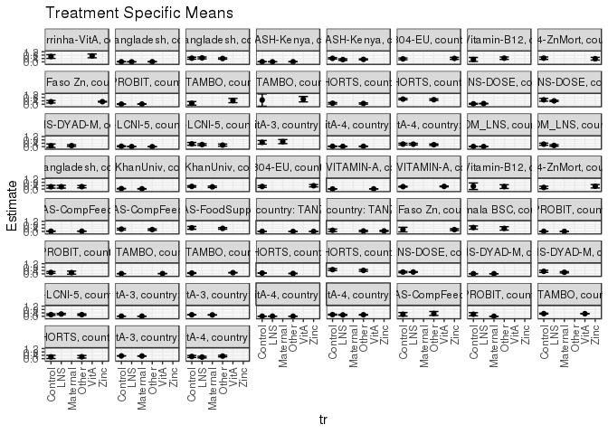

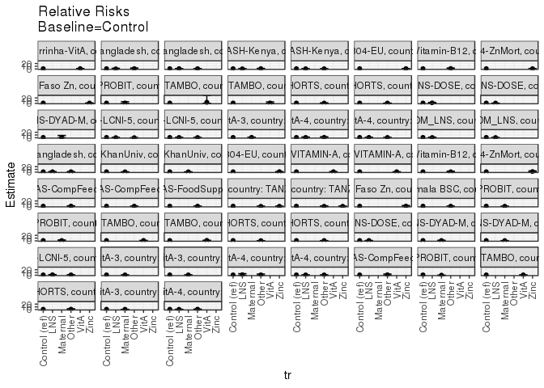

[figure not shown]

[figure not shown]

## Results Table

### Parameter: TSM

| agecat | studyid | country | intXenstunt | intervention_level | baseline_level | estimate | ci_lower | ci_upper |
| --- | --- | --- | --- | --- | --- | --- | --- | --- |
| Birth | ki1000304b-SAS-CompFeed | INDIA | 1_Birth | Control | NA | 0.2352941 | 0.0250435 | 0.4455447 |
| Birth | ki1000304b-SAS-CompFeed | INDIA | 1_Birth | Other | NA | 0.3333333 | 0.0992802 | 0.5673864 |
| Birth | ki1119695-PROBIT | BELARUS | 1_Birth | Control | NA | 0.2380952 | 0.0561598 | 0.4200307 |
| Birth | ki1119695-PROBIT | BELARUS | 1_Birth | Maternal | NA | 0.0000000 | 0.0000000 | 0.0000000 |
| Birth | ki1126311-ZVITAMBO | ZIMBABWE | 1_Birth | Control | NA | 0.3111111 | 0.2632722 | 0.3589500 |
| Birth | ki1126311-ZVITAMBO | ZIMBABWE | 1_Birth | VitA | NA | 0.3069030 | 0.2792845 | 0.3345215 |
| Birth | ki1135781-COHORTS | GUATEMALA | 1_Birth | Control | NA | 0.2105263 | 0.0253522 | 0.3957004 |
| Birth | ki1135781-COHORTS | GUATEMALA | 1_Birth | Other | NA | 0.2258065 | 0.0771283 | 0.3744846 |
| Birth | kiGH5241-JiVitA-3 | BANGLADESH | 1_Birth | Control | NA | 0.3295250 | 0.3126429 | 0.3464070 |
| Birth | kiGH5241-JiVitA-3 | BANGLADESH | 1_Birth | Maternal | NA | 0.3137450 | 0.2927448 | 0.3347453 |
| Birth | kiGH5241-JiVitA-4 | BANGLADESH | 1_Birth | Control | NA | 0.2608696 | 0.1459240 | 0.3758151 |
| Birth | kiGH5241-JiVitA-4 | BANGLADESH | 1_Birth | LNS | NA | 0.1891892 | 0.0951971 | 0.2831813 |
| Birth | kiGH5241-JiVitA-4 | BANGLADESH | 1_Birth | Other | NA | 0.3076923 | 0.2149057 | 0.4004790 |
| 6 months | iLiNS_DYADM_LNS | MALAWI | 0_6 months | Control | NA | 0.0202020 | 0.0041875 | 0.0362166 |
| 6 months | iLiNS_DYADM_LNS | MALAWI | 0_6 months | LNS | NA | 0.0108696 | -0.0013739 | 0.0231131 |
| 6 months | iLiNS_DYADM_LNS | MALAWI | 1_6 months | Control | NA | 0.2962963 | 0.1739496 | 0.4186430 |
| 6 months | iLiNS_DYADM_LNS | MALAWI | 1_6 months | LNS | NA | 0.1428571 | 0.0507879 | 0.2349264 |
| 6 months | ki1000110-WASH-Bangladesh | BANGLADESH | 1_6 months | Control | NA | 0.2758621 | 0.1123732 | 0.4393509 |
| 6 months | ki1000110-WASH-Bangladesh | BANGLADESH | 1_6 months | LNS | NA | 0.2758621 | 0.1123732 | 0.4393509 |
| 6 months | ki1000110-WASH-Bangladesh | BANGLADESH | 1_6 months | Other | NA | 0.2857143 | 0.1484025 | 0.4230261 |
| 6 months | ki1000125-AgaKhanUniv | PAKISTAN | 0_6 months | Control | NA | 0.0524345 | 0.0256705 | 0.0791984 |
| 6 months | ki1000125-AgaKhanUniv | PAKISTAN | 0_6 months | Maternal | NA | 0.0315315 | 0.0085207 | 0.0545423 |
| 6 months | ki1000125-AgaKhanUniv | PAKISTAN | 1_6 months | Control | NA | 0.3148148 | 0.2270088 | 0.4026209 |
| 6 months | ki1000125-AgaKhanUniv | PAKISTAN | 1_6 months | Maternal | NA | 0.2653061 | 0.1776830 | 0.3529292 |
| 6 months | ki1000304-EU | INDIA | 1_6 months | Control | NA | 0.3043478 | 0.1953121 | 0.4133835 |
| 6 months | ki1000304-EU | INDIA | 1_6 months | Zinc | NA | 0.3958333 | 0.2568938 | 0.5347729 |
| 6 months | ki1000304-VITAMIN-A | INDIA | 0_6 months | Control | NA | 0.0167598 | 0.0083473 | 0.0251722 |
| 6 months | ki1000304-VITAMIN-A | INDIA | 0_6 months | VitA | NA | 0.0189944 | 0.0100489 | 0.0279400 |
| 6 months | ki1000304-VITAMIN-A | INDIA | 1_6 months | Control | NA | 0.2864865 | 0.2403863 | 0.3325867 |
| 6 months | ki1000304-VITAMIN-A | INDIA | 1_6 months | VitA | NA | 0.3132184 | 0.2644550 | 0.3619818 |

[output cut: 103 more lines]

### Parameter: E(Y)

| agecat | studyid | country | intXenstunt | intervention_level | baseline_level | estimate | ci_lower | ci_upper |
| --- | --- | --- | --- | --- | --- | --- | --- | --- |
| Birth | ki1000304b-SAS-CompFeed | INDIA | 1_Birth | NA | NA | 0.2894737 | 0.1276124 | 0.4513349 |
| Birth | ki1119695-PROBIT | BELARUS | 1_Birth | NA | NA | 0.1515152 | 0.0311314 | 0.2718989 |
| Birth | ki1126311-ZVITAMBO | ZIMBABWE | 1_Birth | NA | NA | 0.3079609 | 0.2840420 | 0.3318798 |
| Birth | ki1135781-COHORTS | GUATEMALA | 1_Birth | NA | NA | 0.2200000 | 0.1040132 | 0.3359868 |
| Birth | kiGH5241-JiVitA-3 | BANGLADESH | 1_Birth | NA | NA | 0.3220259 | 0.3086698 | 0.3353820 |
| Birth | kiGH5241-JiVitA-4 | BANGLADESH | 1_Birth | NA | NA | 0.2591093 | 0.2008377 | 0.3173809 |
| 6 months | iLiNS_DYADM_LNS | MALAWI | 0_6 months | NA | NA | 0.0157068 | 0.0055172 | 0.0258964 |
| 6 months | iLiNS_DYADM_LNS | MALAWI | 1_6 months | NA | NA | 0.2181818 | 0.1406470 | 0.2957167 |
| 6 months | ki1000110-WASH-Bangladesh | BANGLADESH | 1_6 months | NA | NA | 0.2800000 | 0.1915545 | 0.3684455 |
| 6 months | ki1000125-AgaKhanUniv | PAKISTAN | 0_6 months | NA | NA | 0.0429448 | 0.0249577 | 0.0609319 |
| 6 months | ki1000125-AgaKhanUniv | PAKISTAN | 1_6 months | NA | NA | 0.2912621 | 0.2290671 | 0.3534572 |
| 6 months | ki1000304-EU | INDIA | 1_6 months | NA | NA | 0.3418803 | 0.2555609 | 0.4281998 |
| 6 months | ki1000304-VITAMIN-A | INDIA | 0_6 months | NA | NA | 0.0178771 | 0.0117370 | 0.0240172 |
| 6 months | ki1000304-VITAMIN-A | INDIA | 1_6 months | NA | NA | 0.2994429 | 0.2659180 | 0.3329678 |
| 6 months | ki1000304-Vitamin-B12 | INDIA | 1_6 months | NA | NA | 0.3043478 | 0.1120750 | 0.4966207 |
| 6 months | ki1000304-ZnMort | INDIA | 1_6 months | NA | NA | 0.2500000 | 0.1311597 | 0.3688403 |
| 6 months | ki1000304b-SAS-CompFeed | INDIA | 0_6 months | NA | NA | 0.0328947 | 0.0188786 | 0.0469109 |
| 6 months | ki1000304b-SAS-CompFeed | INDIA | 1_6 months | NA | NA | 0.2484472 | 0.1797369 | 0.3171575 |
| 6 months | ki1000304b-SAS-FoodSuppl | INDIA | 1_6 months | NA | NA | 0.3823529 | 0.3003775 | 0.4643284 |
| 6 months | ki1066203-TanzaniaChild2 | TANZANIA, UNITED REPUBLIC OF | 0_6 months | NA | NA | 0.0100692 | 0.0051588 | 0.0149797 |
| 6 months | ki1066203-TanzaniaChild2 | TANZANIA, UNITED REPUBLIC OF | 1_6 months | NA | NA | 0.0762712 | 0.0281753 | 0.1243670 |
| 6 months | ki1112895-Burkina Faso Zn | BURKINA FASO | 1_6 months | NA | NA | 0.2191781 | 0.1236224 | 0.3147337 |
| 6 months | ki1112895-Guatemala BSC | GUATEMALA | 1_6 months | NA | NA | 0.4166667 | 0.2757209 | 0.5576124 |
| 6 months | ki1119695-PROBIT | BELARUS | 0_6 months | NA | NA | 0.0147386 | 0.0094772 | 0.0200000 |
| 6 months | ki1119695-PROBIT | BELARUS | 1_6 months | NA | NA | 0.1551724 | 0.0461778 | 0.2641670 |
| 6 months | ki1126311-ZVITAMBO | ZIMBABWE | 0_6 months | NA | NA | 0.0325588 | 0.0283925 | 0.0367251 |
| 6 months | ki1126311-ZVITAMBO | ZIMBABWE | 1_6 months | NA | NA | 0.1293532 | 0.1061419 | 0.1525646 |
| 6 months | ki1135781-COHORTS | GUATEMALA | 0_6 months | NA | NA | 0.0703325 | 0.0523990 | 0.0882660 |
| 6 months | ki1135781-COHORTS | GUATEMALA | 1_6 months | NA | NA | 0.4533333 | 0.3734005 | 0.5332661 |
| 6 months | ki1148112-iLiNS-DOSE | MALAWI | 1_6 months | NA | NA | 0.2178388 | 0.1843035 | 0.2513741 |
| 6 months | ki1148112-iLiNS-DYAD-M | MALAWI | 0_6 months | NA | NA | 0.0185400 | 0.0095349 | 0.0275450 |
| 6 months | ki1148112-iLiNS-DYAD-M | MALAWI | 1_6 months | NA | NA | 0.2228916 | 0.1593886 | 0.2863945 |
| 6 months | ki1148112-LCNI-5 | MALAWI | 1_6 months | NA | NA | 0.2297735 | 0.1827914 | 0.2767555 |
| 6 months | kiGH5241-JiVitA-3 | BANGLADESH | 0_6 months | NA | NA | 0.0138432 | 0.0115228 | 0.0161635 |
| 6 months | kiGH5241-JiVitA-3 | BANGLADESH | 1_6 months | NA | NA | 0.1693788 | 0.1569537 | 0.1818040 |
| 6 months | kiGH5241-JiVitA-4 | BANGLADESH | 0_6 months | NA | NA | 0.0092029 | 0.0049847 | 0.0134211 |
| 6 months | kiGH5241-JiVitA-4 | BANGLADESH | 1_6 months | NA | NA | 0.1759154 | 0.1524585 | 0.1993723 |
| 24 months | ki1000107-Serrinha-VitA | BRAZIL | 1_24 months | NA | NA | 0.6666667 | 0.5104930 | 0.8228403 |
| 24 months | ki1000110-WASH-Bangladesh | BANGLADESH | 0_24 months | NA | NA | 0.0124153 | 0.0051201 | 0.0197106 |
| 24 months | ki1000110-WASH-Bangladesh | BANGLADESH | 1_24 months | NA | NA | 0.4252492 | 0.3693058 | 0.4811926 |
| 24 months | ki1000111-WASH-Kenya | KENYA | 0_24 months | NA | NA | 0.0161201 | 0.0102989 | 0.0219412 |
| 24 months | ki1000111-WASH-Kenya | KENYA | 1_24 months | NA | NA | 0.3311828 | 0.2883598 | 0.3740058 |
| 24 months | ki1000304-EU | INDIA | 1_24 months | NA | NA | 0.3809524 | 0.3021809 | 0.4597239 |
| 24 months | ki1000304-Vitamin-B12 | INDIA | 1_24 months | NA | NA | 0.4032258 | 0.2801246 | 0.5263270 |
| 24 months | ki1000304-ZnMort | INDIA | 1_24 months | NA | NA | 0.4096386 | 0.3031996 | 0.5160775 |
| 24 months | ki1112895-Burkina Faso Zn | BURKINA FASO | 1_24 months | NA | NA | 0.3053613 | 0.2617285 | 0.3489941 |
| 24 months | ki1119695-PROBIT | BELARUS | 0_24 months | NA | NA | 0.0214541 | 0.0054705 | 0.0374378 |
| 24 months | ki1126311-ZVITAMBO | ZIMBABWE | 0_24 months | NA | NA | 0.3200000 | 0.1333741 | 0.5066259 |
| 24 months | ki1126311-ZVITAMBO | ZIMBABWE | 1_24 months | NA | NA | 0.5833333 | 0.2919904 | 0.8746763 |
| 24 months | ki1135781-COHORTS | GUATEMALA | 0_24 months | NA | NA | 0.1047619 | 0.0459043 | 0.1636195 |
| 24 months | ki1135781-COHORTS | GUATEMALA | 1_24 months | NA | NA | 0.5782609 | 0.5143000 | 0.6422217 |
| 24 months | ki1148112-iLiNS-DOSE | MALAWI | 0_24 months | NA | NA | 0.0756458 | 0.0533634 | 0.0979281 |
| 24 months | ki1148112-iLiNS-DOSE | MALAWI | 1_24 months | NA | NA | 0.4230769 | 0.3596405 | 0.4865134 |
| 24 months | ki1148112-iLiNS-DYAD-M | MALAWI | 0_24 months | NA | NA | 0.1200000 | 0.0290124 | 0.2109876 |
| 24 months | ki1148112-LCNI-5 | MALAWI | 0_24 months | NA | NA | 0.0200000 | 0.0026109 | 0.0373891 |
| 24 months | ki1148112-LCNI-5 | MALAWI | 1_24 months | NA | NA | 0.2518519 | 0.1783561 | 0.3253476 |
| 24 months | kiGH5241-JiVitA-3 | BANGLADESH | 1_24 months | NA | NA | 0.5538462 | 0.3953431 | 0.7123492 |
| 24 months | kiGH5241-JiVitA-4 | BANGLADESH | 0_24 months | NA | NA | 0.0386965 | 0.0234186 | 0.0539745 |
| 24 months | kiGH5241-JiVitA-4 | BANGLADESH | 1_24 months | NA | NA | 0.2711864 | 0.2173023 | 0.3250706 |

### Parameter: RR

| agecat | studyid | country | intXenstunt | intervention_level | baseline_level | estimate | ci_lower | ci_upper |
| --- | --- | --- | --- | --- | --- | --- | --- | --- |
| Birth | ki1000304b-SAS-CompFeed | INDIA | 1_Birth | Control | Control | 1.0000000 | 1.0000000 | 1.0000000 |
| Birth | ki1000304b-SAS-CompFeed | INDIA | 1_Birth | Other | Control | 1.4166667 | 0.4552207 | 4.4087289 |
| Birth | ki1119695-PROBIT | BELARUS | 1_Birth | Control | Control | 1.0000000 | 1.0000000 | 1.0000000 |
| Birth | ki1119695-PROBIT | BELARUS | 1_Birth | Maternal | Control | 0.0000000 | 0.0000000 | 0.0000000 |
| Birth | ki1126311-ZVITAMBO | ZIMBABWE | 1_Birth | Control | Control | 1.0000000 | 1.0000000 | 1.0000000 |
| Birth | ki1126311-ZVITAMBO | ZIMBABWE | 1_Birth | VitA | Control | 0.9864739 | 0.8254853 | 1.1788589 |
| Birth | ki1135781-COHORTS | GUATEMALA | 1_Birth | Control | Control | 1.0000000 | 1.0000000 | 1.0000000 |
| Birth | ki1135781-COHORTS | GUATEMALA | 1_Birth | Other | Control | 1.0725806 | 0.3574880 | 3.2180923 |
| Birth | kiGH5241-JiVitA-3 | BANGLADESH | 1_Birth | Control | Control | 1.0000000 | 1.0000000 | 1.0000000 |
| Birth | kiGH5241-JiVitA-3 | BANGLADESH | 1_Birth | Maternal | Control | 0.9521131 | 0.8751418 | 1.0358542 |
| Birth | kiGH5241-JiVitA-4 | BANGLADESH | 1_Birth | Control | Control | 1.0000000 | 1.0000000 | 1.0000000 |
| Birth | kiGH5241-JiVitA-4 | BANGLADESH | 1_Birth | LNS | Control | 0.7252252 | 0.3733155 | 1.4088664 |
| Birth | kiGH5241-JiVitA-4 | BANGLADESH | 1_Birth | Other | Control | 1.1794872 | 0.6915390 | 2.0117304 |
| 6 months | iLiNS_DYADM_LNS | MALAWI | 0_6 months | Control | Control | 1.0000000 | 1.0000000 | 1.0000000 |
| 6 months | iLiNS_DYADM_LNS | MALAWI | 0_6 months | LNS | Control | 0.5380435 | 0.1357147 | 2.1330834 |
| 6 months | iLiNS_DYADM_LNS | MALAWI | 1_6 months | Control | Control | 1.0000000 | 1.0000000 | 1.0000000 |
| 6 months | iLiNS_DYADM_LNS | MALAWI | 1_6 months | LNS | Control | 0.4821429 | 0.2242638 | 1.0365550 |
| 6 months | ki1000110-WASH-Bangladesh | BANGLADESH | 1_6 months | Control | Control | 1.0000000 | 1.0000000 | 1.0000000 |
| 6 months | ki1000110-WASH-Bangladesh | BANGLADESH | 1_6 months | LNS | Control | 1.0000000 | 0.4325188 | 2.3120383 |
| 6 months | ki1000110-WASH-Bangladesh | BANGLADESH | 1_6 months | Other | Control | 1.0357143 | 0.4829085 | 2.2213401 |
| 6 months | ki1000125-AgaKhanUniv | PAKISTAN | 0_6 months | Control | Control | 1.0000000 | 1.0000000 | 1.0000000 |
| 6 months | ki1000125-AgaKhanUniv | PAKISTAN | 0_6 months | Maternal | Control | 0.6013514 | 0.2468097 | 1.4651914 |
| 6 months | ki1000125-AgaKhanUniv | PAKISTAN | 1_6 months | Control | Control | 1.0000000 | 1.0000000 | 1.0000000 |
| 6 months | ki1000125-AgaKhanUniv | PAKISTAN | 1_6 months | Maternal | Control | 0.8427371 | 0.5469558 | 1.2984701 |
| 6 months | ki1000304-EU | INDIA | 1_6 months | Control | Control | 1.0000000 | 1.0000000 | 1.0000000 |
| 6 months | ki1000304-EU | INDIA | 1_6 months | Zinc | Control | 1.3005952 | 0.7876271 | 2.1476508 |
| 6 months | ki1000304-VITAMIN-A | INDIA | 0_6 months | Control | Control | 1.0000000 | 1.0000000 | 1.0000000 |
| 6 months | ki1000304-VITAMIN-A | INDIA | 0_6 months | VitA | Control | 1.1333333 | 0.5694246 | 2.2556879 |
| 6 months | ki1000304-VITAMIN-A | INDIA | 1_6 months | Control | Control | 1.0000000 | 1.0000000 | 1.0000000 |
| 6 months | ki1000304-VITAMIN-A | INDIA | 1_6 months | VitA | Control | 1.0933095 | 0.8739852 | 1.3676727 |

[output cut: 103 more lines]

### Parameter: PAR

| agecat | studyid | country | intXenstunt | intervention_level | baseline_level | estimate | ci_lower | ci_upper |
| --- | --- | --- | --- | --- | --- | --- | --- | --- |
| Birth | ki1000304b-SAS-CompFeed | INDIA | 1_Birth | Control | NA | 0.0541796 | -0.1230434 | 0.2314025 |
| Birth | ki1119695-PROBIT | BELARUS | 1_Birth | Control | NA | -0.0865801 | -0.1811093 | 0.0079491 |
| Birth | ki1126311-ZVITAMBO | ZIMBABWE | 1_Birth | Control | NA | -0.0031502 | -0.0445024 | 0.0382019 |
| Birth | ki1135781-COHORTS | GUATEMALA | 1_Birth | Control | NA | 0.0094737 | -0.1377758 | 0.1567232 |
| Birth | kiGH5241-JiVitA-3 | BANGLADESH | 1_Birth | Control | NA | -0.0074991 | -0.0203332 | 0.0053350 |
| Birth | kiGH5241-JiVitA-4 | BANGLADESH | 1_Birth | Control | NA | -0.0017603 | -0.0978053 | 0.0942848 |
| 6 months | iLiNS_DYADM_LNS | MALAWI | 0_6 months | Control | NA | -0.0044952 | -0.0142126 | 0.0052222 |
| 6 months | iLiNS_DYADM_LNS | MALAWI | 1_6 months | Control | NA | -0.0781145 | -0.1573850 | 0.0011560 |
| 6 months | ki1000110-WASH-Bangladesh | BANGLADESH | 1_6 months | Control | NA | 0.0041379 | -0.1338788 | 0.1421547 |
| 6 months | ki1000125-AgaKhanUniv | PAKISTAN | 0_6 months | Control | NA | -0.0094897 | -0.0255402 | 0.0065608 |
| 6 months | ki1000125-AgaKhanUniv | PAKISTAN | 1_6 months | Control | NA | -0.0235527 | -0.0826624 | 0.0355571 |
| 6 months | ki1000304-EU | INDIA | 1_6 months | Control | NA | 0.0375325 | -0.0353864 | 0.1104514 |
| 6 months | ki1000304-VITAMIN-A | INDIA | 0_6 months | Control | NA | 0.0011173 | -0.0050228 | 0.0072574 |
| 6 months | ki1000304-VITAMIN-A | INDIA | 1_6 months | Control | NA | 0.0129564 | -0.0195828 | 0.0454956 |
| 6 months | ki1000304-Vitamin-B12 | INDIA | 1_6 months | Control | NA | -0.0289855 | -0.3577817 | 0.2998107 |
| 6 months | ki1000304-ZnMort | INDIA | 1_6 months | Control | NA | 0.0564516 | -0.0451872 | 0.1580904 |
| 6 months | ki1000304b-SAS-CompFeed | INDIA | 0_6 months | Control | NA | 0.0009313 | -0.0139936 | 0.0158562 |
| 6 months | ki1000304b-SAS-CompFeed | INDIA | 1_6 months | Control | NA | -0.0278686 | -0.1038550 | 0.0481179 |
| 6 months | ki1000304b-SAS-FoodSuppl | INDIA | 1_6 months | Control | NA | -0.0462185 | -0.1871469 | 0.0947099 |
| 6 months | ki1066203-TanzaniaChild2 | TANZANIA, UNITED REPUBLIC OF | 0_6 months | Control | NA | -0.0073005 | -0.0175149 | 0.0029139 |
| 6 months | ki1066203-TanzaniaChild2 | TANZANIA, UNITED REPUBLIC OF | 1_6 months | Control | NA | -0.0600924 | -0.1838639 | 0.0636790 |
| 6 months | ki1112895-Burkina Faso Zn | BURKINA FASO | 1_6 months | Control | NA | -0.0030441 | -0.2589448 | 0.2528565 |
| 6 months | ki1112895-Guatemala BSC | GUATEMALA | 1_6 months | Control | NA | -0.0448718 | -0.1742577 | 0.0845141 |
| 6 months | ki1119695-PROBIT | BELARUS | 0_6 months | Control | NA | -0.0035385 | -0.0086099 | 0.0015329 |
| 6 months | ki1119695-PROBIT | BELARUS | 1_6 months | Control | NA | -0.0114943 | -0.1228509 | 0.0998624 |
| 6 months | ki1126311-ZVITAMBO | ZIMBABWE | 0_6 months | Control | NA | 0.0036404 | -0.0033460 | 0.0106267 |
| 6 months | ki1126311-ZVITAMBO | ZIMBABWE | 1_6 months | Control | NA | 0.0330965 | -0.0055778 | 0.0717709 |
| 6 months | ki1135781-COHORTS | GUATEMALA | 0_6 months | Control | NA | -0.0244044 | -0.0430063 | -0.0058024 |
| 6 months | ki1135781-COHORTS | GUATEMALA | 1_6 months | Control | NA | -0.0466667 | -0.1298915 | 0.0365582 |
| 6 months | ki1148112-iLiNS-DOSE | MALAWI | 1_6 months | Control | NA | -0.0012089 | -0.0728723 | 0.0704546 |
| 6 months | ki1148112-iLiNS-DYAD-M | MALAWI | 0_6 months | Control | NA | -0.0016620 | -0.0143500 | 0.0110259 |
| 6 months | ki1148112-iLiNS-DYAD-M | MALAWI | 1_6 months | Control | NA | -0.0734047 | -0.1695636 | 0.0227541 |
| 6 months | ki1148112-LCNI-5 | MALAWI | 1_6 months | Control | NA | 0.0353290 | -0.0464287 | 0.1170867 |
| 6 months | kiGH5241-JiVitA-3 | BANGLADESH | 0_6 months | Control | NA | -0.0015995 | -0.0039887 | 0.0007898 |
| 6 months | kiGH5241-JiVitA-3 | BANGLADESH | 1_6 months | Control | NA | -0.0078070 | -0.0198876 | 0.0042735 |
| 6 months | kiGH5241-JiVitA-4 | BANGLADESH | 0_6 months | Control | NA | 0.0013904 | -0.0062959 | 0.0090767 |
| 6 months | kiGH5241-JiVitA-4 | BANGLADESH | 1_6 months | Control | NA | -0.0188295 | -0.0621168 | 0.0244577 |
| 24 months | ki1000107-Serrinha-VitA | BRAZIL | 1_24 months | Control | NA | 0.0350877 | -0.1122280 | 0.1824034 |
| 24 months | ki1000110-WASH-Bangladesh | BANGLADESH | 0_24 months | Control | NA | -0.0025847 | -0.0170437 | 0.0118744 |
| 24 months | ki1000110-WASH-Bangladesh | BANGLADESH | 1_24 months | Control | NA | -0.0113705 | -0.1122834 | 0.0895423 |
| 24 months | ki1000111-WASH-Kenya | KENYA | 0_24 months | Control | NA | -0.0020919 | -0.0105337 | 0.0063500 |
| 24 months | ki1000111-WASH-Kenya | KENYA | 1_24 months | Control | NA | -0.0854839 | -0.1471877 | -0.0237800 |
| 24 months | ki1000304-EU | INDIA | 1_24 months | Control | NA | 0.0265220 | -0.0467356 | 0.0997796 |
| 24 months | ki1000304-Vitamin-B12 | INDIA | 1_24 months | Control | NA | 0.1175115 | -0.0978159 | 0.3328389 |
| 24 months | ki1000304-ZnMort | INDIA | 1_24 months | Control | NA | -0.0278614 | -0.1184532 | 0.0627304 |
| 24 months | ki1112895-Burkina Faso Zn | BURKINA FASO | 1_24 months | Control | NA | 0.0080640 | -0.1329830 | 0.1491110 |
| 24 months | ki1119695-PROBIT | BELARUS | 0_24 months | Control | NA | 0.0026874 | -0.0155195 | 0.0208942 |
| 24 months | ki1126311-ZVITAMBO | ZIMBABWE | 0_24 months | Control | NA | 0.2088889 | -0.0081934 | 0.4259711 |
| 24 months | ki1126311-ZVITAMBO | ZIMBABWE | 1_24 months | Control | NA | 0.0833333 | -0.5755325 | 0.7421992 |
| 24 months | ki1135781-COHORTS | GUATEMALA | 0_24 months | Control | NA | -0.0152381 | -0.0773209 | 0.0468447 |
| 24 months | ki1135781-COHORTS | GUATEMALA | 1_24 months | Control | NA | -0.0333094 | -0.0941024 | 0.0274836 |
| 24 months | ki1148112-iLiNS-DOSE | MALAWI | 0_24 months | Control | NA | 0.0207007 | -0.0235162 | 0.0649176 |
| 24 months | ki1148112-iLiNS-DOSE | MALAWI | 1_24 months | Control | NA | -0.1032389 | -0.2485470 | 0.0420693 |
| 24 months | ki1148112-iLiNS-DYAD-M | MALAWI | 0_24 months | Control | NA | 0.0088889 | -0.1803441 | 0.1981219 |
| 24 months | ki1148112-LCNI-5 | MALAWI | 0_24 months | Control | NA | -0.0312821 | -0.0660229 | 0.0034588 |
| 24 months | ki1148112-LCNI-5 | MALAWI | 1_24 months | Control | NA | -0.0814815 | -0.2183096 | 0.0553466 |
| 24 months | kiGH5241-JiVitA-3 | BANGLADESH | 1_24 months | Control | NA | 0.0395604 | -0.1073978 | 0.1865187 |
| 24 months | kiGH5241-JiVitA-4 | BANGLADESH | 0_24 months | Control | NA | 0.0013632 | -0.0283355 | 0.0310619 |
| 24 months | kiGH5241-JiVitA-4 | BANGLADESH | 1_24 months | Control | NA | -0.0343691 | -0.1234288 | 0.0546906 |

### Parameter: PAF

| agecat | studyid | country | intXenstunt | intervention_level | baseline_level | estimate | ci_lower | ci_upper |
| --- | --- | --- | --- | --- | --- | --- | --- | --- |
| Birth | ki1000304b-SAS-CompFeed | INDIA | 1_Birth | Control | NA | 0.1871658 | -0.6932502 | 0.6098040 |
| Birth | ki1119695-PROBIT | BELARUS | 1_Birth | Control | NA | -0.5714286 | -1.2954661 | -0.0757674 |
| Birth | ki1126311-ZVITAMBO | ZIMBABWE | 1_Birth | Control | NA | -0.0102293 | -0.1538391 | 0.1155065 |
| Birth | ki1135781-COHORTS | GUATEMALA | 1_Birth | Control | NA | 0.0430622 | -0.9255912 | 0.5244422 |
| Birth | kiGH5241-JiVitA-3 | BANGLADESH | 1_Birth | Control | NA | -0.0232872 | -0.0641096 | 0.0159692 |
| Birth | kiGH5241-JiVitA-4 | BANGLADESH | 1_Birth | Control | NA | -0.0067935 | -0.4547964 | 0.3032474 |
| 6 months | iLiNS_DYADM_LNS | MALAWI | 0_6 months | Control | NA | -0.2861953 | -1.0369647 | 0.1878611 |
| 6 months | iLiNS_DYADM_LNS | MALAWI | 1_6 months | Control | NA | -0.3580247 | -0.7675050 | -0.0434093 |
| 6 months | ki1000110-WASH-Bangladesh | BANGLADESH | 1_6 months | Control | NA | 0.0147783 | -0.6248522 | 0.4026153 |
| 6 months | ki1000125-AgaKhanUniv | PAKISTAN | 0_6 months | Control | NA | -0.2209738 | -0.6442433 | 0.0933355 |
| 6 months | ki1000125-AgaKhanUniv | PAKISTAN | 1_6 months | Control | NA | -0.0808642 | -0.3040116 | 0.1040974 |
| 6 months | ki1000304-EU | INDIA | 1_6 months | Control | NA | 0.1097826 | -0.1310529 | 0.2993369 |
| 6 months | ki1000304-VITAMIN-A | INDIA | 0_6 months | Control | NA | 0.0625000 | -0.3513824 | 0.3496243 |
| 6 months | ki1000304-VITAMIN-A | INDIA | 1_6 months | Control | NA | 0.0432684 | -0.0717869 | 0.1459726 |
| 6 months | ki1000304-Vitamin-B12 | INDIA | 1_6 months | Control | NA | -0.0952381 | -1.9367301 | 0.5915367 |
| 6 months | ki1000304-ZnMort | INDIA | 1_6 months | Control | NA | 0.2258065 | -0.2972782 | 0.5379745 |
| 6 months | ki1000304b-SAS-CompFeed | INDIA | 0_6 months | Control | NA | 0.0283105 | -0.5603157 | 0.3948786 |
| 6 months | ki1000304b-SAS-CompFeed | INDIA | 1_6 months | Control | NA | -0.1121711 | -0.4706076 | 0.1589025 |
| 6 months | ki1000304b-SAS-FoodSuppl | INDIA | 1_6 months | Control | NA | -0.1208791 | -0.5577794 | 0.1934866 |
| 6 months | ki1066203-TanzaniaChild2 | TANZANIA, UNITED REPUBLIC OF | 0_6 months | Control | NA | -0.7250310 | -1.9974413 | 0.0072426 |
| 6 months | ki1066203-TanzaniaChild2 | TANZANIA, UNITED REPUBLIC OF | 1_6 months | Control | NA | -0.7878788 | -3.2981960 | 0.2563135 |
| 6 months | ki1112895-Burkina Faso Zn | BURKINA FASO | 1_6 months | Control | NA | -0.0138889 | -2.2070122 | 0.6794616 |
| 6 months | ki1112895-Guatemala BSC | GUATEMALA | 1_6 months | Control | NA | -0.1076923 | -0.4677584 | 0.1640434 |
| 6 months | ki1119695-PROBIT | BELARUS | 0_6 months | Control | NA | -0.2400862 | -0.6006663 | 0.0392665 |
| 6 months | ki1119695-PROBIT | BELARUS | 1_6 months | Control | NA | -0.0740741 | -1.1492758 | 0.4632447 |
| 6 months | ki1126311-ZVITAMBO | ZIMBABWE | 0_6 months | Control | NA | 0.1118087 | -0.1303354 | 0.3020799 |
| 6 months | ki1126311-ZVITAMBO | ZIMBABWE | 1_6 months | Control | NA | 0.2558618 | -0.1079903 | 0.5002287 |
| 6 months | ki1135781-COHORTS | GUATEMALA | 0_6 months | Control | NA | -0.3469856 | -0.6246163 | -0.1167993 |
| 6 months | ki1135781-COHORTS | GUATEMALA | 1_6 months | Control | NA | -0.1029412 | -0.3035657 | 0.0668063 |
| 6 months | ki1148112-iLiNS-DOSE | MALAWI | 1_6 months | Control | NA | -0.0055493 | -0.3947185 | 0.2750297 |
| 6 months | ki1148112-iLiNS-DYAD-M | MALAWI | 0_6 months | Control | NA | -0.0896464 | -1.0394670 | 0.4178237 |
| 6 months | ki1148112-iLiNS-DYAD-M | MALAWI | 1_6 months | Control | NA | -0.3293293 | -0.8356213 | 0.0373197 |
| 6 months | ki1148112-LCNI-5 | MALAWI | 1_6 months | Control | NA | 0.1537559 | -0.2875065 | 0.4437860 |
| 6 months | kiGH5241-JiVitA-3 | BANGLADESH | 0_6 months | Control | NA | -0.1155416 | -0.2991516 | 0.0421187 |
| 6 months | kiGH5241-JiVitA-3 | BANGLADESH | 1_6 months | Control | NA | -0.0460921 | -0.1200281 | 0.0229632 |
| 6 months | kiGH5241-JiVitA-4 | BANGLADESH | 0_6 months | Control | NA | 0.1510837 | -1.3104066 | 0.6880813 |
| 6 months | kiGH5241-JiVitA-4 | BANGLADESH | 1_6 months | Control | NA | -0.1070374 | -0.3817595 | 0.1130643 |
| 24 months | ki1000107-Serrinha-VitA | BRAZIL | 1_24 months | Control | NA | 0.0526316 | -0.1974488 | 0.2504841 |
| 24 months | ki1000110-WASH-Bangladesh | BANGLADESH | 0_24 months | Control | NA | -0.2081818 | -2.1515156 | 0.5368250 |
| 24 months | ki1000110-WASH-Bangladesh | BANGLADESH | 1_24 months | Control | NA | -0.0267386 | -0.2937221 | 0.1851480 |
| 24 months | ki1000111-WASH-Kenya | KENYA | 0_24 months | Control | NA | -0.1297671 | -0.7927583 | 0.2880392 |
| 24 months | ki1000111-WASH-Kenya | KENYA | 1_24 months | Control | NA | -0.2581169 | -0.4597843 | -0.0843096 |
| 24 months | ki1000304-EU | INDIA | 1_24 months | Control | NA | 0.0696203 | -0.1440936 | 0.2434129 |
| 24 months | ki1000304-Vitamin-B12 | INDIA | 1_24 months | Control | NA | 0.2914286 | -0.5048557 | 0.6663644 |
| 24 months | ki1000304-ZnMort | INDIA | 1_24 months | Control | NA | -0.0680147 | -0.3141460 | 0.1320177 |
| 24 months | ki1112895-Burkina Faso Zn | BURKINA FASO | 1_24 months | Control | NA | 0.0264081 | -0.5646551 | 0.3941916 |
| 24 months | ki1119695-PROBIT | BELARUS | 0_24 months | Control | NA | 0.1252606 | -1.3291598 | 0.6714829 |
| 24 months | ki1126311-ZVITAMBO | ZIMBABWE | 0_24 months | Control | NA | 0.6527778 | -0.9670074 | 0.9387073 |
| 24 months | ki1126311-ZVITAMBO | ZIMBABWE | 1_24 months | Control | NA | 0.1428571 | -2.2131661 | 0.7713489 |
| 24 months | ki1135781-COHORTS | GUATEMALA | 0_24 months | Control | NA | -0.1454545 | -0.9146696 | 0.3147297 |
| 24 months | ki1135781-COHORTS | GUATEMALA | 1_24 months | Control | NA | -0.0576027 | -0.1685408 | 0.0428033 |
| 24 months | ki1148112-iLiNS-DOSE | MALAWI | 0_24 months | Control | NA | 0.2736532 | -0.6132475 | 0.6729704 |
| 24 months | ki1148112-iLiNS-DOSE | MALAWI | 1_24 months | Control | NA | -0.2440191 | -0.6416825 | 0.0573185 |
| 24 months | ki1148112-iLiNS-DYAD-M | MALAWI | 0_24 months | Control | NA | 0.0740741 | -4.0800877 | 0.8312354 |
| 24 months | ki1148112-LCNI-5 | MALAWI | 0_24 months | Control | NA | -1.5641025 | -3.0417372 | -0.6266822 |
| 24 months | ki1148112-LCNI-5 | MALAWI | 1_24 months | Control | NA | -0.3235294 | -0.9939360 | 0.1214713 |
| 24 months | kiGH5241-JiVitA-3 | BANGLADESH | 1_24 months | Control | NA | 0.0714286 | -0.2355869 | 0.3021576 |
| 24 months | kiGH5241-JiVitA-4 | BANGLADESH | 0_24 months | Control | NA | 0.0352281 | -1.1447827 | 0.5660237 |
| 24 months | kiGH5241-JiVitA-4 | BANGLADESH | 1_24 months | Control | NA | -0.1267361 | -0.5091049 | 0.1587501 |